# 《社交文本与数据分析》上机考试

## 一、数据读取

### 1、主观题：读取评论数据，只保留P_name和P_remark两列，预览前5条数据

```python
import pandas as pd

# 读取数据
df = pd.read_excel(r'E:\上机考试\数据\reviews.xlsx')
df = df[['P_name', 'P_remark']]  # 保留指定列

# 预览前5条数据
df.head()
```

|  | P_name | P_remark |
| --- | --- | --- |
| 0 | HUAWEI Pura 70 Ultra超聚光伸缩摄像头 超高速风驰闪拍 双卫星通信 华为官... | 手机拍照很好看，成像很清晰，而且续航也很顶，冲电速度也很快，不错的一款手机！ |
| 1 | HUAWEI Pura 70 Ultra超聚光伸缩摄像头 超高速风驰闪拍 双卫星通信 华为官... | 非常喜欢华为品牌，华为手机非常好用，性能很强，会继续支持国产。pura 70非常好看，发货速... |
| 2 | HUAWEI Pura 70 Ultra超聚光伸缩摄像头 超高速风驰闪拍 双卫星通信 华为官... | 真是太幸运了能抢到新款华为手机，头天晚上抢到的第二天上午就送到了快递物流发货真是超快，而且手... |
| 3 | HUAWEI Pura 70 Ultra超聚光伸缩摄像头 超高速风驰闪拍 双卫星通信 华为官... | 这款 HUAWEI Pura 70 Ultra 真的太让人惊喜了！它的性能强劲，无论是运行大... |
| 4 | HUAWEI Pura 70 Ultra超聚光伸缩摄像头 超高速风驰闪拍 双卫星通信 华为官... | 你好 Pura，很幸运的抢到了第一批，拿到快递的时候太兴奋了。正面是四边微曲玻璃，后面是素皮... |

### 2、读取停止词数据，并在停止词列表中通过append()函数添加“华为”和“手机”两个词。

```python
# 读取停止词
with open(r'E:\上机考试\数据\stoplist.txt', 'r', encoding='utf-8') as f:
    stopwords = f.read().splitlines()

# 添加新词
stopwords.append('华为')
stopwords.append('手机')
```

### 3、分别读取知网情感词典文件，将读取出来的"正面评价词语"和"正面情感词语"合并成一个列表，作为正面情感词典，将"负面评价词语”和"负面情感词语"合并成一个列表，作为负面情感词典。

```python
# 读取正面词典
with open(r'E:\上机考试\数据\正面评价词语.txt', 'r', encoding='utf-8') as f:
    positive_eval = f.read().splitlines()
with open(r'E:\上机考试\数据\正面情感词语.txt', 'r', encoding='utf-8') as f:
    positive_emo = f.read().splitlines()

# 读取负面词典
with open(r'E:\上机考试\数据\负面评价词语.txt', 'r', encoding='utf-8') as f:
    negative_eval = f.read().splitlines()
with open(r'E:\上机考试\数据\负面情感词语.txt', 'r', encoding='utf-8') as f:
    negative_emo = f.read().splitlines()

# 合并词典
positive_words = positive_eval + positive_emo
negative_words = negative_eval + negative_emo
```

## 二、数据清洗与预览

### 1、原始评论数据多少条，空评论有多少条，评论显示“此用户没有填写评价”的数据有多少条，数据清洗后的有效数据多少条？编程打印这些数字

```python
# 原始评论数据条数
total_records = len(df)
print(f"原始评论数据条数: {total_records}")

# 空评论数量
empty_comments = df['P_remark'].isnull().sum()
print(f"空评论数量: {empty_comments}")

# "此用户没有填写评价"的数量
no_comment_count = (df['P_remark'] == '此用户没有填写评价').sum()
print(f"评论显示'此用户没有填写评价'的数据条数: {no_comment_count}")

# 数据清洗后的有效数据
df_clean = df.dropna(subset=['P_remark'])
df_clean = df_clean[df_clean['P_remark'] != '此用户没有填写评价']
valid_records = len(df_clean)
print(f"数据清洗后的有效数据条数: {valid_records}")
```

```
原始评论数据条数: 13044
空评论数量: 116
评论显示'此用户没有填写评价'的数据条数: 0
数据清洗后的有效数据条数: 12928
```

### 2、正面情感词典中的词语数为多少个，负面情感词典中的词语数为多少个？

```python
print(f"正面情感词典中的词语数: {len(positive_words)}")
print(f"负面情感词典中的词语数: {len(negative_words)}")
```

```
正面情感词典中的词语数: 4580
负面情感词典中的词语数: 4391
```

### 3、去除无效评论后，按商品标题进行分类汇总，统计每个商品标题对应的评论数，用DataFrame表格显示评论数最多的前五种商品(至少要有商品标题和评论数两列)。

```python
# 统计每个商品的评论数
product_stats = df_clean['P_name'].value_counts().reset_index()
product_stats.columns = ['商品标题', '评论数']

# 显示评论数最多的前5种商品
product_stats.head()
```

|  | 商品标题 | 评论数 |
| --- | --- | --- |
| 0 | HUAWEI Pura 70 Ultra超聚光伸缩摄像头 超高速风驰闪拍 双卫星通信 华为官... | 177 |
| 1 | 华为FreeBuds SE2无线耳机蓝牙耳机长续航华为耳机半入耳官方正品 | 177 |
| 2 | HUAWEI Pura 70 Pro+超高速风驰闪拍 超聚光微距长焦 双卫星通信 华为官方旗... | 177 |
| 3 | 华为路由AX3双频合一 自动优选家用路由器双核wifi6+千兆端口3000M无线速率上网保护... | 177 |
| 4 | 华为智能体脂秤3WiFi&蓝牙双连接13/14项身体数据蓝牙版健身必备精准测量塑形减脂小物称重 | 177 |

## 三、文本分析与词频统计

### 1、使用jieba库对数据集中的评论文本字段进行分词。分词的同时，对分词结果进行筛选:只保留中文、去除停用词，注意需要保留单字词。

```python
import jieba

# 分词处理
df_clean['分词结果'] = df_clean['P_remark'].apply(
    lambda text: [word for word in jieba.lcut(str(text))
                 if all('\u4e00' <= char <= '\u9fff' for char in word)
                 and word not in stopwords]
)

df_clean[['P_name', '分词结果']].head()
```

```
Building prefix dict from the default dictionary ...
Dumping model to file cache C:\Users\Admin\AppData\Local\Temp\jieba.cache
Loading model cost 0.688 seconds.
Prefix dict has been built successfully.
```

|  | P_name | 分词结果 |
| --- | --- | --- |
| 0 | HUAWEI Pura 70 Ultra超聚光伸缩摄像头 超高速风驰闪拍 双卫星通信 华为官... | [拍照, 好看, 成像, 清晰, 续航, 顶, 冲电, 速度, 很快, 不错, 一款] |
| 1 | HUAWEI Pura 70 Ultra超聚光伸缩摄像头 超高速风驰闪拍 双卫星通信 华为官... | [喜欢, 品牌, 好用, 性能, 很强, 支持, 国产, 好看, 发货, 速度, 满意] |
| 2 | HUAWEI Pura 70 Ultra超聚光伸缩摄像头 超高速风驰闪拍 双卫星通信 华为官... | [真是太, 幸运, 抢, 新款, 头天, 晚上, 抢到, 第二天, 上午, 送到, 快递, ... |
| 3 | HUAWEI Pura 70 Ultra超聚光伸缩摄像头 超高速风驰闪拍 双卫星通信 华为官... | [款, 真的, 太, 惊喜, 性能, 强劲, 无论是, 运行, 大型软件, 多任务处理, 流... |
| 4 | HUAWEI Pura 70 Ultra超聚光伸缩摄像头 超高速风驰闪拍 双卫星通信 华为官... | [你好, 幸运, 抢, 第一批, 拿到, 快递, 太, 兴奋, 正面, 四边, 微曲, 玻璃... |

### 2、对分词之后的所有词语进行词频统计，输出频数最高的前10个词。

```python
from collections import Counter

# 将所有分词结果合并
all_words = []
for words_list in df_clean['分词结果']:
    all_words.extend(words_list)

# 统计词频
word_counts = Counter(all_words)

# 输出前10个高频词
word_counts.most_common(10)
```

```
[('不错', 3194),
 ('外观', 3004),
 ('效果', 2271),
 ('喜欢', 1880),
 ('功能', 1767),
 ('速度', 1760),
 ('材质', 1734),
 ('续航', 1578),
 ('很快', 1504),
 ('真的', 1452)]
```

### 3、将频数最高的前100个词，绘制成词云图。要求背景色为白色，不显示坐标轴。

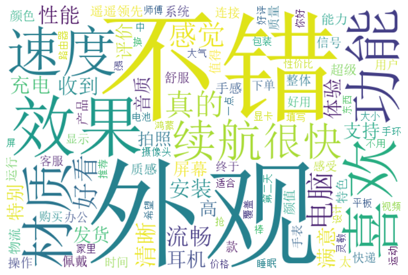

```python
from wordcloud import WordCloud
import matplotlib.pyplot as plt

# 获取前100个高频词
top_100_words = dict(word_counts.most_common(100))

# 生成词云
wc = WordCloud(
    background_color='white',
    width=600,
    height=400,
    font_path=r'C:\Windows\Fonts\simsun.ttc'
)

wc.generate_from_frequencies(top_100_words)

# 绘制
plt.figure(figsize=(10, 8))
plt.imshow(wc, interpolation='bilinear')
plt.axis('off')
plt.show()
```

### 4、用代码np.random.seed(124)来设置随机数种子，其中xxx为你自己学号的后三位。利用np.random.choice函数随机选择三条评论数据，分别打印出分词前和分词后的评论文本。

```python
import numpy as np

np.random.seed(124)

# 随机选择3条数据的索引
random_indices = np.random.choice(df_clean.index, 3, replace=False)

for idx in random_indices:
    print(f"原始评论: {df_clean.loc[idx, 'P_remark']}")
    print(f"分词结果: {df_clean.loc[idx, '分词结果']}")
    print("-" * 50)
```

```
原始评论: 先用看看再追评
分词结果: ['先', '追评']
--------------------------------------------------
原始评论: 买来送给老公的礼物，他很喜欢，质量很好
分词结果: ['买来', '送给', '老公', '礼物', '喜欢', '质量']
--------------------------------------------------
原始评论: 这发货速度可是真快啊，赶上空投了！哈哈，外观颜值可是真高级，还是磁吸盖设计，这样以后清洗也比较方便。开启后，声音很小，让我最满意的就是它很小巧，这样就算外出携带方便多啦！敲满意👍～
分词结果: ['发货', '速度', '真快', '赶上', '空投', '外观', '颜值', '真', '高级', '磁吸盖', '设计', '清洗', '开启', '声音', '很小', '满意', '小巧', '外出', '携带方便', '敲', '满意']
--------------------------------------------------
```

## 四、主题模型分析

### 1、使用scikit-learn库提取评论文本的TF特征(设置最大特征维度为800)

```python
from sklearn.feature_extraction.text import TfidfVectorizer

# 将分词结果转换为字符串
df_clean['分词文本'] = df_clean['分词结果'].apply(lambda x: ' '.join(x))

# 提取TF特征
vectorizer = TfidfVectorizer(max_features=800, use_idf=False)
tf_features = vectorizer.fit_transform(df_clean['分词文本'])

# 查看特征维度
print(f"TF特征矩阵形状: {tf_features.shape}")
```

```
TF特征矩阵形状: (12928, 800)
```

### 2、计算不同主题数量对应的困惑度，并将所有的困惑度值绘制成拆线图，确定最佳的主题数量

```
主题数: 2, 困惑度: 481.76
主题数: 3, 困惑度: 558.28
主题数: 4, 困惑度: 620.80
主题数: 5, 困惑度: 665.46
主题数: 6, 困惑度: 734.37
主题数: 7, 困惑度: 767.06
主题数: 8, 困惑度: 803.55
主题数: 9, 困惑度: 848.85
主题数: 10, 困惑度: 875.28
```

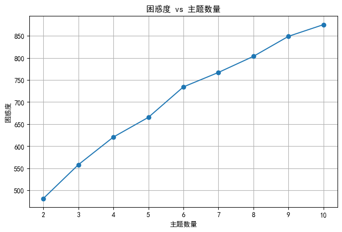

```
最佳主题数量: 2
```

```python
from sklearn.decomposition import LatentDirichletAllocation
import matplotlib.pyplot as plt

# 主题数量范围
topic_range = range(2, 11)
perplexities = []

# 计算不同主题数的困惑度
for n_topics in topic_range:
    lda = LatentDirichletAllocation(n_components=n_topics, random_state=124)
    lda.fit(tf_features)
    perplexity = lda.perplexity(tf_features)
    perplexities.append(perplexity)
    print(f"主题数: {n_topics}, 困惑度: {perplexity:.2f}")

# 设置中文字体
plt.rcParams['font.sans-serif'] = ['SimHei']
plt.rcParams['axes.unicode_minus'] = False

# 绘制折线图
plt.figure(figsize=(8, 5))
plt.plot(topic_range, perplexities, marker='o')
plt.xlabel('主题数量')
plt.ylabel('困惑度')
plt.title('困惑度 vs 主题数量')
plt.grid(True)
plt.show()

# 找到最佳主题数（困惑度最小）
best_topic = topic_range[perplexities.index(min(perplexities))]
print(f"\n最佳主题数量: {best_topic}")
```

### 3、使用TF特征进行LDA建模分析，打分别打印出每个主题下面概率值最高的前10个词。

```python
best_topic = 2
lda_model = LatentDirichletAllocation(n_components=best_topic, random_state=124)
lda_model.fit(tf_features)

# 获取特征词
feature_names = vectorizer.get_feature_names_out()

# 打印每个主题的前10个词
for topic_idx, topic in enumerate(lda_model.components_):
    print(f"主题 {topic_idx + 1}:")
    top_words_idx = topic.argsort()[-10:][::-1]
    top_words = [feature_names[i] for i in top_words_idx]
    print(" ".join(top_words))
    print()
```

```
主题 1:
很快 评价 安装 速度 支持 发货 用户 充电 物流 收到

主题 2:
不错 外观 喜欢 效果 材质 续航 好看 功能 电脑 感觉
```

## 五、文本情感分析

### 1、计算出所有出现在情感词典中的词的极性

```python
# 创建情感极性词典
sentiment_dict = {}
for word in positive_words:
    sentiment_dict[word] = 1  # 正面
for word in negative_words:
    sentiment_dict[word] = -1  # 负面

print(f"情感词典大小: {len(sentiment_dict)}")
```

```
情感词典大小: 8785
```

### 2、绘制所有的正面情感词语的词云图(背景为白色，不显示坐标轴)

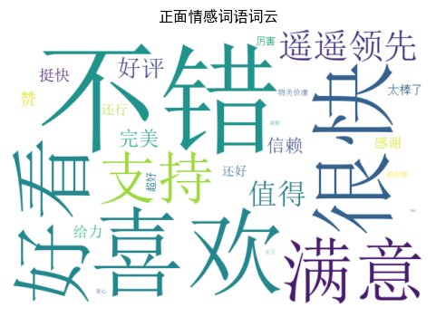

```python
# 筛选正面情感词
positive_dict = {}
for word, freq in word_counts.items():
    if word in sentiment_dict and sentiment_dict[word] == 1:
        positive_dict[word] = freq

# 生成词云
wc_positive = WordCloud(
    background_color='white',
    width=600,
    height=400,
    font_path=r'C:\Windows\Fonts\simsun.ttc'
)

wc_positive.generate_from_frequencies(positive_dict)

# 绘制
plt.figure(figsize=(6, 4))
plt.imshow(wc_positive, interpolation='bilinear')
plt.title('正面情感词语词云')
plt.axis('off')
plt.show()
```

### 3、绘制所有的负面情感词语的词云图(背景为白色，不显示坐标轴)

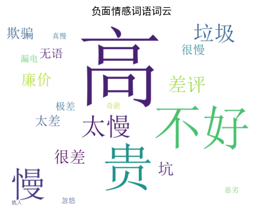

```python
# 筛选负面情感词
negative_dict = {}
for word, freq in word_counts.items():
    if word in sentiment_dict and sentiment_dict[word] == -1:
        negative_dict[word] = freq

# 生成负面词云
wc_negative = WordCloud(
    background_color='white',
    width=800,
    height=600,
    font_path=r'C:\Windows\Fonts\simsun.ttc'
)

wc_negative.generate_from_frequencies(negative_dict)

# 绘制
plt.figure(figsize=(6, 4))
plt.imshow(wc_negative, interpolation='bilinear')
plt.title('负面情感词语词云')
plt.axis('off')
plt.show()
```

### 4、利用snownlp库计算每条有效评论的情感得分。

```python
from snownlp import SnowNLP

# 计算情感得分
df_clean['情感得分'] = df_clean['P_remark'].apply(lambda x: SnowNLP(str(x)).sentiments)

# 查看结果
df_clean[['P_remark', '情感得分']].head()
```

|  | P_remark | 情感得分 |
| --- | --- | --- |
| 0 | 手机拍照很好看，成像很清晰，而且续航也很顶，冲电速度也很快，不错的一款手机！ | 0.999837 |
| 1 | 非常喜欢华为品牌，华为手机非常好用，性能很强，会继续支持国产。pura 70非常好看，发货速... | 0.999901 |
| 2 | 真是太幸运了能抢到新款华为手机，头天晚上抢到的第二天上午就送到了快递物流发货真是超快，而且手... | 1.000000 |
| 3 | 这款 HUAWEI Pura 70 Ultra 真的太让人惊喜了！它的性能强劲，无论是运行大... | 1.000000 |
| 4 | 你好 Pura，很幸运的抢到了第一批，拿到快递的时候太兴奋了。正面是四边微曲玻璃，后面是素皮... | 0.999995 |

### 5、将情感得分按照0.5的阈值划分极性，最终封装成DataFrame格式并预览前5行数据，新封装的DataFrame只有"评论”、“得分”和"极性"三列。

```python
# 创建新的DataFrame
sentiment_df = pd.DataFrame({
    '评论': df_clean['P_remark'],
    '得分': df_clean['情感得分'],
    '极性': df_clean['情感得分'].apply(lambda x: '正面' if x >= 0.5 else '负面')
})

# 预览前5行数据
sentiment_df.head()
```

|  | 评论 | 得分 | 极性 |
| --- | --- | --- | --- |
| 0 | 手机拍照很好看，成像很清晰，而且续航也很顶，冲电速度也很快，不错的一款手机！ | 0.999837 | 正面 |
| 1 | 非常喜欢华为品牌，华为手机非常好用，性能很强，会继续支持国产。pura 70非常好看，发货速... | 0.999901 | 正面 |
| 2 | 真是太幸运了能抢到新款华为手机，头天晚上抢到的第二天上午就送到了快递物流发货真是超快，而且手... | 1.000000 | 正面 |
| 3 | 这款 HUAWEI Pura 70 Ultra 真的太让人惊喜了！它的性能强劲，无论是运行大... | 1.000000 | 正面 |
| 4 | 你好 Pura，很幸运的抢到了第一批，拿到快递的时候太兴奋了。正面是四边微曲玻璃，后面是素皮... | 0.999995 | 正面 |

### 6、统计正面评论和负面评论各有多少条，绘制饼图。

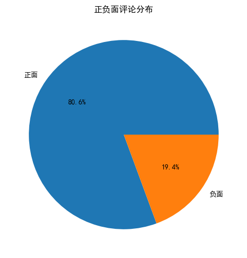

```
正面评论: 10421条
负面评论: 2507条
```

```python
# 统计正负面评论数量
sentiment_counts = sentiment_df['极性'].value_counts()

# 设置中文字体
plt.rcParams['font.sans-serif'] = ['SimHei']
plt.rcParams['axes.unicode_minus'] = False

# 绘制饼图
plt.figure(figsize=(6, 6))
plt.pie(sentiment_counts.values, labels=sentiment_counts.index, autopct='%1.1f%%')
plt.title('正负面评论分布')
plt.show()

print(f"正面评论: {sentiment_counts.get('正面', 0)}条")
print(f"负面评论: {sentiment_counts.get('负面', 0)}条")
```